# Seq_analysis

Alice Osmaston

2024-04-30

```r
# Load necessary packages
pacman::p_load(tidyverse, dplyr, knitr, here, ggplot2)

# Import the datasets from pore pore scan plot
porecount2 <- read_csv(here("data", "porecount2.csv"))
```

## Run performance will be assessed by two measures and compared between the four runs:

- Phenol + no fragmentation
- Phenol + fragmentation
- Zymo kit + no fragmentation
- Zymo kit + fragmentation

## 1. Adjusted predicted output and 2. Pore depletion rate over time

### 1. Adjusted predicted output

We cannot directly compare the data output from each of the four runs because there are additional factors which have influence as well as the properties of the library pool istelf and how it was prepared. If we control for two key variables then we can predict what the output would have been, if certain variables had been equal across the runs.

We have found that the there are two key attributes of the flow cell which impact total run output. These are “Initial number of pores available” and “Percentage of pores sequencing” at the start of the run. The inital number of pores available is related to the age of the flow cell but also varies between flow cells within the same batch.The first pore scan performed in a sequencing run returns the number of available pores. A higher number of pores available at the beginning of a run will result in higher data output. The “Percentage of pores sequencing” is related to the amount (fmol) of library pool you load to the flow cell. Despite selecting a loading concentration (18fmol) and diluting the library to this value, there is room for error given the tiny volumes of liqued involved <2uL and so “Percentage of pores sequencing” can be a proxy for loading concentration (fmol). If we are to compare the data output (Gb) for 4 runs with different sets of samples, we must control for these two variables across the four runs.

Our evidence from other runs suggests that loading concentration is directly correlated with “Percentage of sequencing pores” and that this can be used as a proxy.

```r
# Creating the dataframe
pores_data <- data.frame(
  Run = c("Run 1", "Run 2", "Run 3", "Run 4"),
  Input_concentration_fmol = c(20, 50, 65, 70),
  Percent_Sequencing_Pores = c(37.2, 66.4, 80, 82.4)
)

# Viewing the dataframe
print(pores_data)
```

```
##     Run Input_concentration_fmol Percent_Sequencing_Pores
## 1 Run 1                       20                     37.2
## 2 Run 2                       50                     66.4
## 3 Run 3                       65                     80.0
## 4 Run 4                       70                     82.4
```

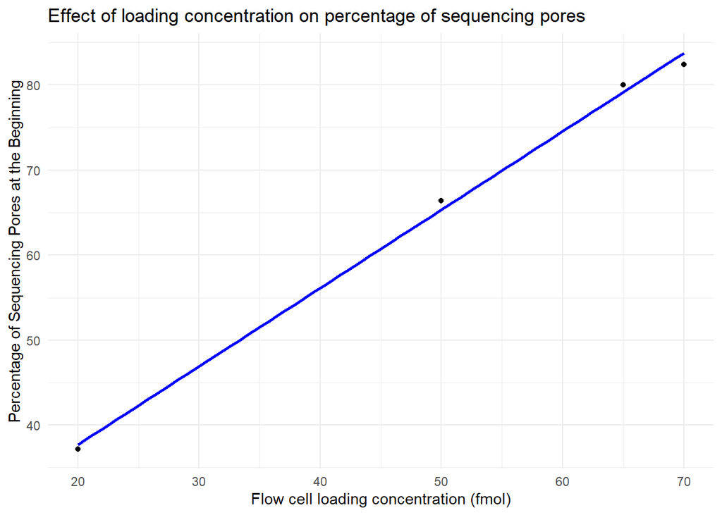

```r
# Create the scatter plot
ggplot(pores_data, aes(x = Input_concentration_fmol, y = Percent_Sequencing_Pores)) +
  geom_point() +
  geom_smooth(method = "lm", se = FALSE, color = "blue") +
  labs(x = "Flow cell loading concentration (fmol)", y = "Percentage of Sequencing Pores at the Beginning") +
  ggtitle("Effect of loading concentration on percentage of sequencing pores") +
  theme_minimal()
```

The top half of the following table was use to predict the expected data output from each flow cell if it had started with 63.3% sequencing pores at the start, and 1264 pores at the beginning.

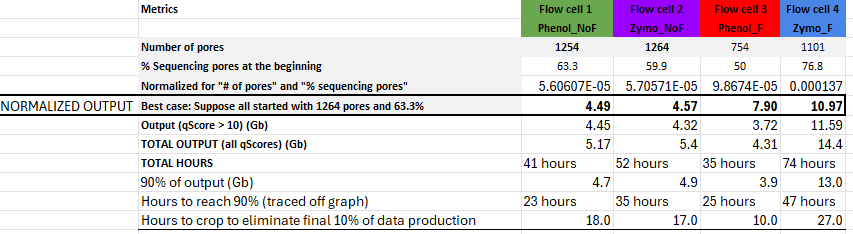

We can see that the predicted data output for Zymo + Fragmentation condition is the highest. Within both the Phenol pair and the Zymo kit pair of flow cells, the one with fragmentation outperforms no fragmentation. Within the fragmented pair and the pair not fragmented, the Zymo kit outperforms the Phenol condition although the predicted values are very close between phenol not fragmented condition and the zymo not fragmented condition.

The bottom half of the table was used to calcualte how many hours to crop off the end of the run which will be used in later analysis.

## 2. Pore depletion rate over time

# Plot the pore count data (number of active pores)

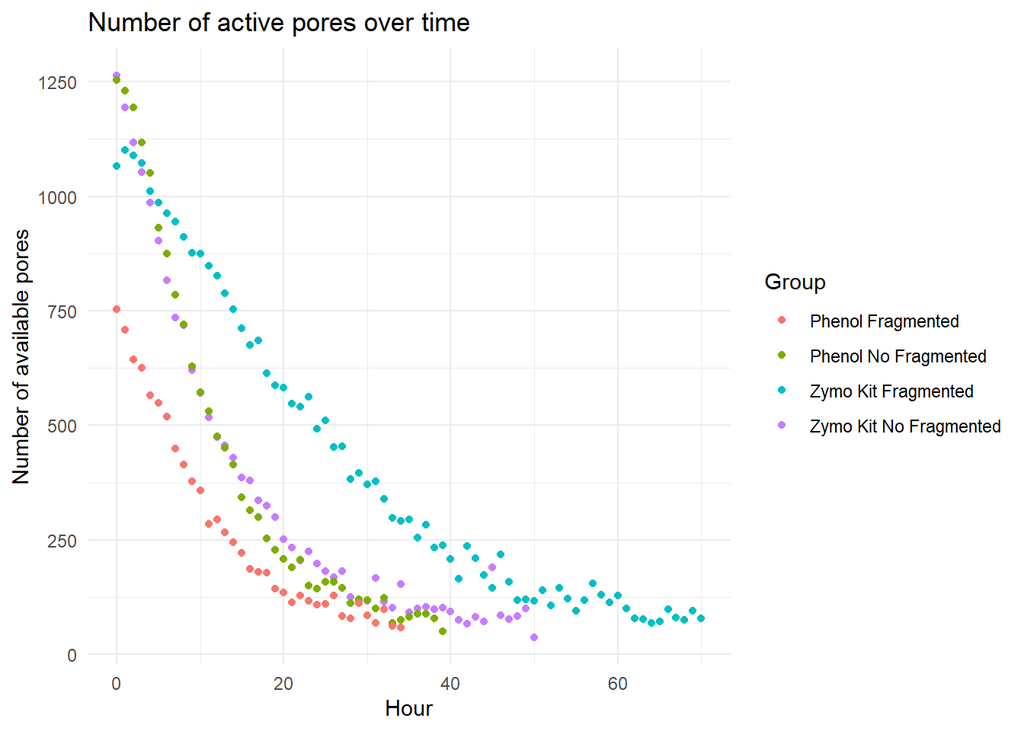

```r
# Plot the raw data
ggplot(data=porecount2, aes(x=Hour, y=`Number of available pores`, color=Group))+ geom_point() + labs(title= "Number of active pores over time") + theme_minimal()
```

The data was log transformed to linearise it.

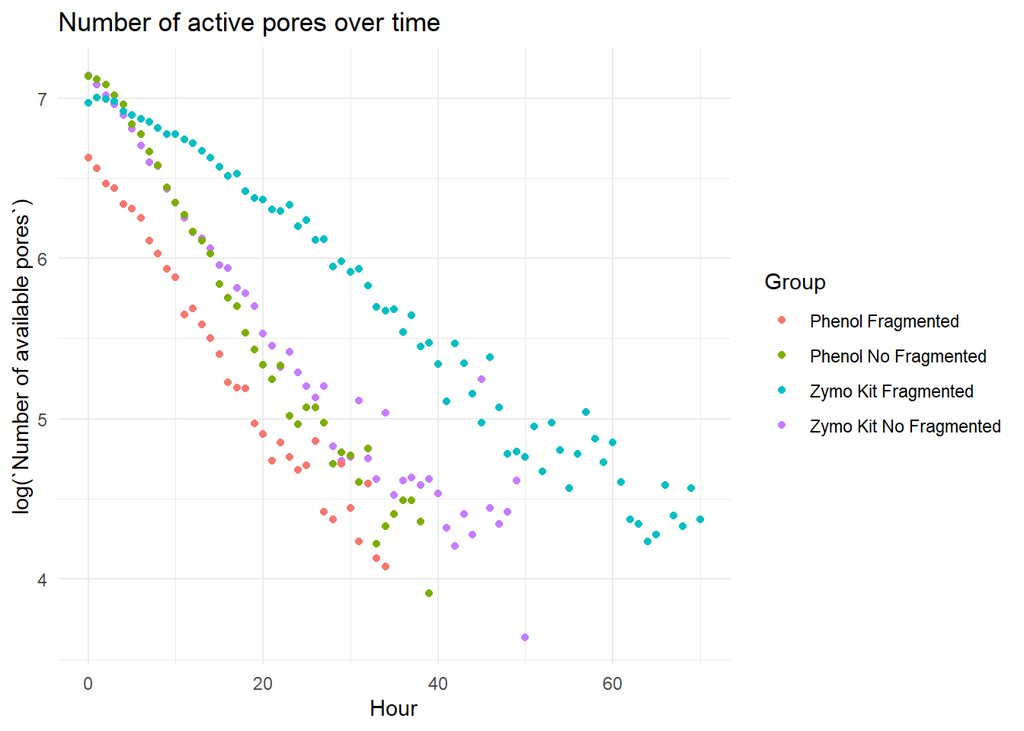

```r
# plot the data using a log transformation on the y axis to make the data linear
ggplot(data=porecount2, aes(x=Hour, y=log(`Number of available pores`),color=Group))+ geom_point() + labs(title= "Number of active pores over time") + theme_minimal()
```

Edit data to crop the first hour (hour 0) from each run. Because in some cases the number of available rises before falling. Later we will also removed the final part of the run, where percentage of pores sequencing is variable and non-informative as it tails off towards zero.

### Apply a linear model to the data with the first hour cropped and normalised to all begin from the same point.

```r
# Import dataset with first hour removed and normalised pore count column adjusted to the value in hour=1.
porecount3 <- read_csv(here("data", "porecount3.csv"))
# Apply simple linear regression model
lm_1 <- lm(log(`Number of available pores`) ~ Hour * Group, data = porecount3)

# summarise simple linear regression model
summary(lm_1)
```

```
##
## Call:
## lm(formula = log(`Number of available pores`) ~ Hour * Group,
##     data = porecount3)
##
## Residuals:
##      Min       1Q   Median       3Q      Max
## -0.43684 -0.09893  0.00719  0.07618  1.02418
##
## Coefficients:
##                                   Estimate Std. Error t value Pr(>|t|)
## (Intercept)                       6.574475   0.063732 103.158  < 2e-16 ***
## Hour                             -0.074493   0.003177 -23.450  < 2e-16 ***
## GroupPhenol No Fragmented         0.573869   0.087078   6.590 4.49e-10 ***
## GroupZymo Kit Fragmented          0.546496   0.077578   7.044 3.60e-11 ***
## GroupZymo Kit No Fragmented       0.320810   0.082368   3.895 0.000137 ***
## Hour:GroupPhenol No Fragmented   -0.006560   0.004096  -1.602 0.110960
## Hour:GroupZymo Kit Fragmented     0.031813   0.003361   9.465  < 2e-16 ***
## Hour:GroupZymo Kit No Fragmented  0.015106   0.003642   4.148 5.12e-05 ***
## ---
## Signif. codes:  0 '***' 0.001 '**' 0.01 '*' 0.05 '.' 0.1 ' ' 1
##
## Residual standard error: 0.1817 on 184 degrees of freedom
## Multiple R-squared:  0.9586, Adjusted R-squared:  0.957
## F-statistic: 608.9 on 7 and 184 DF,  p-value: < 2.2e-16
```

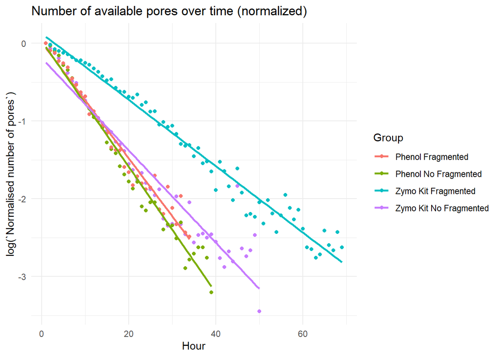

```r
# Plot overlaid linear model
ggplot(data=porecount3, aes(x=Hour, y=log(`Normalised number of pores`),color=Group))+ geom_point() + labs(title= "Number of available pores over time (normalized)") + geom_smooth(method = "lm", formula = y ~ x, se = FALSE) + theme_minimal()
```

The highly disperse points at the final hours of each run seem to impact the slope of the line. We should crop the final hours of each run. We will still interpret the model to compare with the next (cropped) model.

### Interpretation of linear model coefficients:

Rate of decrease of available pores in Phenol Fragmented group = Baseline = -0.074493

Phenol No Fragmented = -0.074493 + -0.006560 = -0.081053

Zymo Kit Fragmented = -0.074493 + 0.031813 = -0.04268

Zymo Kit No Fragmented = -0.074493 + 0.015106 = -0.059387

## Pairwise comparisons

### Phenol No Fragmented vs Zymo No Fragmented. RESULT = Zymo No Fragmented is better (sig = ***)

```r
lm_comparison1 <- lm(log(`Normalised number of pores`) ~ Hour * Group,
                              data = porecount3[porecount3$Group == 'Zymo Kit No Fragmented' |
                                                 porecount3$Group == 'Phenol No Fragmented',])
summary(lm_comparison1)
```

```
##
## Call:
## lm(formula = log(`Normalised number of pores`) ~ Hour * Group,
##     data = porecount3[porecount3$Group == "Zymo Kit No Fragmented" |
##         porecount3$Group == "Phenol No Fragmented", ])
##
## Residuals:
##      Min       1Q   Median       3Q      Max
## -0.43684 -0.14290 -0.00491  0.09525  1.02418
##
## Coefficients:
##                                   Estimate Std. Error t value Pr(>|t|)
## (Intercept)                       0.033575   0.071779   0.468   0.6412
## Hour                             -0.081053   0.003128 -25.915  < 2e-16 ***
## GroupZymo Kit No Fragmented      -0.222516   0.095586  -2.328   0.0223 *
## Hour:GroupZymo Kit No Fragmented  0.021666   0.003798   5.705 1.66e-07 ***
## ---
## Signif. codes:  0 '***' 0.001 '**' 0.01 '*' 0.05 '.' 0.1 ' ' 1
##
## Residual standard error: 0.2198 on 85 degrees of freedom
## Multiple R-squared:  0.9442, Adjusted R-squared:  0.9422
## F-statistic: 479.2 on 3 and 85 DF,  p-value: < 2.2e-16
```

### Phenol No Fragmented vs Phenol Fragmented. RESULT = Phenol fragmented is better (sig = *)

```r
lm_comparison2 <- lm(log(`Normalised number of pores`) ~ Hour * Group,
                              data = porecount3[porecount3$Group == 'Phenol Fragmented' |
                                                 porecount3$Group == 'Phenol No Fragmented',])
summary(lm_comparison2)
```

```
##
## Call:
## lm(formula = log(`Normalised number of pores`) ~ Hour * Group,
##     data = porecount3[porecount3$Group == "Phenol Fragmented" |
##         porecount3$Group == "Phenol No Fragmented", ])
##
## Residuals:
##      Min       1Q   Median       3Q      Max
## -0.27391 -0.09892  0.01094  0.07933  0.40444
##
## Coefficients:
##                                 Estimate Std. Error t value Pr(>|t|)
## (Intercept)                     0.012031   0.050748   0.237   0.8133
## Hour                           -0.074493   0.002529 -29.450   <2e-16 ***
## GroupPhenol No Fragmented       0.021543   0.069337   0.311   0.7570
## Hour:GroupPhenol No Fragmented -0.006560   0.003261  -2.011   0.0482 *
## ---
## Signif. codes:  0 '***' 0.001 '**' 0.01 '*' 0.05 '.' 0.1 ' ' 1
##
## Residual standard error: 0.1447 on 69 degrees of freedom
## Multiple R-squared:  0.9731, Adjusted R-squared:  0.9719
## F-statistic: 831.1 on 3 and 69 DF,  p-value: < 2.2e-16
```

# Remove final seqeuncing hours from each condition after 90% of data has been generated

Now cut off the final sequencing hours which is uninformative and highly variable and disperse and only accounts for a small amount of the data output. We keep only the linear region of each plot.

Now cut off the final part of the sequencing run to remove variablitiy and keep only the linear region of each plot.

Hours to cut off from each run:

- **Phenol Fragmented:**  
  90% = Cut off 10 hours
- **Phenol No Fragmented:**  
  90% = Cut off 18 hours
- **Zymo Kit Fragmented:**  
  90% = Cut off 27 hours
- **Zymo Kit No Fragmented:**  
  90% = Cut off 17 hours

```r
# Calculate the maximum hour for each group
max_hours <- porecount3 %>%
  group_by(Group) %>%
  summarise(MaxHour = max(Hour))
# Merge the maximum hours with the original data
porecount3 <- porecount3 %>%
  left_join(max_hours, by = "Group")
```

```r
# Applying the crop conditions for each group
cropped_90_count <- porecount3 %>%
  filter(
    (Group == "Zymo Kit Fragmented" & Hour <= (MaxHour - 27)) |
    (Group == "Zymo Kit No Fragmented" & Hour <= (MaxHour - 17)) |
    (Group == "Phenol No Fragmented" & Hour <= (MaxHour - 18)) |
    (Group == "Phenol Fragmented" & Hour <= (MaxHour - 10))
  )
```

```r
# simple linear regression model
lm2 <- lm(log(`Normalised number of pores`) ~ Hour * Group, data = cropped_90_count)

# summarise simple linear regression model
summary(lm2)
```

```
##
## Call:
## lm(formula = log(`Normalised number of pores`) ~ Hour * Group,
##     data = cropped_90_count)
##
## Residuals:
##      Min       1Q   Median       3Q      Max
## -0.30870 -0.03632  0.01160  0.04299  0.35577
##
## Coefficients:
##                                   Estimate Std. Error t value Pr(>|t|)
## (Intercept)                       0.133261   0.031964   4.169 6.05e-05 ***
## Hour                             -0.086804   0.002237 -38.803  < 2e-16 ***
## GroupPhenol No Fragmented         0.070286   0.046905   1.498  0.13683
## GroupZymo Kit Fragmented          0.019224   0.039873   0.482  0.63065
## GroupZymo Kit No Fragmented      -0.070637   0.041857  -1.688  0.09427 .
## Hour:GroupPhenol No Fragmented   -0.010362   0.003532  -2.933  0.00407 **
## Hour:GroupZymo Kit Fragmented     0.043532   0.002437  17.866  < 2e-16 ***
## Hour:GroupZymo Kit No Fragmented  0.009686   0.002632   3.680  0.00036 ***
## ---
## Signif. codes:  0 '***' 0.001 '**' 0.01 '*' 0.05 '.' 0.1 ' ' 1
##
## Residual standard error: 0.07586 on 112 degrees of freedom
## Multiple R-squared:  0.9872, Adjusted R-squared:  0.9864
## F-statistic:  1231 on 7 and 112 DF,  p-value: < 2.2e-16
```

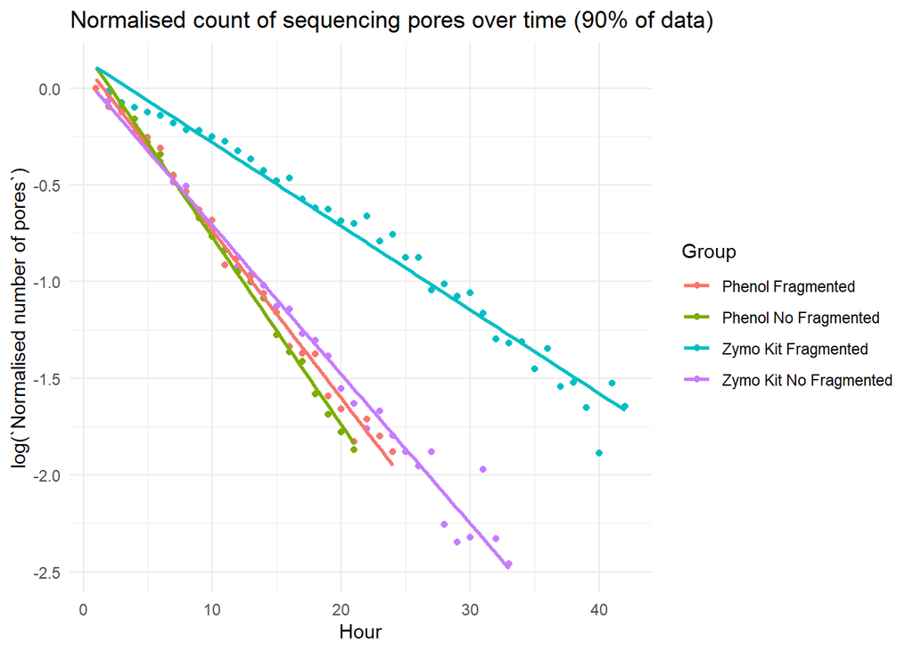

```r
# Plot overlaid linear model
ggplot(data=cropped_90_count, aes(x=Hour, y=log(`Normalised number of pores`),color=Group))+ geom_point() + labs(title= "Normalised count of sequencing pores over time (90% of data)") + geom_smooth(method = "lm", formula = y ~ x, se = FALSE) + theme_minimal()
```

### Interpretation of linear model coefficients: Rate of decrease of

available pores in Phenol Fragmented group = Baseline = -0.086804

Phenol No Fragmented = -0.086804 + -0.010362 = -0.097166

Zymo Kit No Fragmented = -0.086804 + 0.009686 = -0.077118

## Pairwise comparisons

### Phenol No Fragmented vs Zymo No Fragmented. RESULT = Zymo No Fragmented is better 0.02 (sig = ***)

```r
lm_comparison3 <- lm(log(`Normalised number of pores`) ~ Hour * Group,
                              data = cropped_90_count[cropped_90_count$Group == 'Zymo Kit No Fragmented' |
                                                 cropped_90_count$Group == 'Phenol No Fragmented',])
summary(lm_comparison3)
```

```
##
## Call:
## lm(formula = log(`Normalised number of pores`) ~ Hour * Group,
##     data = cropped_90_count[cropped_90_count$Group == "Zymo Kit No Fragmented" |
##         cropped_90_count$Group == "Phenol No Fragmented", ])
##
## Residuals:
##      Min       1Q   Median       3Q      Max
## -0.17425 -0.03339 -0.00156  0.02776  0.35577
##
## Coefficients:
##                                   Estimate Std. Error t value Pr(>|t|)
## (Intercept)                       0.203547   0.034858   5.839 3.89e-07 ***
## Hour                             -0.097166   0.002776 -35.001  < 2e-16 ***
## GroupZymo Kit No Fragmented      -0.140922   0.044364  -3.177  0.00255 **
## Hour:GroupZymo Kit No Fragmented  0.020048   0.003113   6.440 4.51e-08 ***
## ---
## Signif. codes:  0 '***' 0.001 '**' 0.01 '*' 0.05 '.' 0.1 ' ' 1
##
## Residual standard error: 0.07703 on 50 degrees of freedom
## Multiple R-squared:  0.9891, Adjusted R-squared:  0.9885
## F-statistic:  1514 on 3 and 50 DF,  p-value: < 2.2e-16
```

### Phenol No Fragmented vs Phenol Fragmented. RESULT = Phenol no fragmented is worse -0.01 (sig = ***)

```r
lm_comparison4 <- lm(log(`Normalised number of pores`) ~ Hour * Group,
                              data = cropped_90_count[cropped_90_count$Group == 'Phenol Fragmented' |
                                                 cropped_90_count$Group == 'Phenol No Fragmented',])
summary(lm_comparison4)
```

```
##
## Call:
## lm(formula = log(`Normalised number of pores`) ~ Hour * Group,
##     data = cropped_90_count[cropped_90_count$Group == "Phenol Fragmented" |
##         cropped_90_count$Group == "Phenol No Fragmented", ])
##
## Residuals:
##       Min        1Q    Median        3Q       Max
## -0.136633 -0.035944  0.009025  0.033944  0.077020
##
## Coefficients:
##                                 Estimate Std. Error t value Pr(>|t|)
## (Intercept)                     0.133261   0.022067   6.039 3.81e-07 ***
## Hour                           -0.086804   0.001544 -56.208  < 2e-16 ***
## GroupPhenol No Fragmented       0.070286   0.032381   2.171  0.03581 *
## Hour:GroupPhenol No Fragmented -0.010362   0.002439  -4.249  0.00012 ***
## ---
## Signif. codes:  0 '***' 0.001 '**' 0.01 '*' 0.05 '.' 0.1 ' ' 1
##
## Residual standard error: 0.05237 on 41 degrees of freedom
## Multiple R-squared:  0.993,  Adjusted R-squared:  0.9925
## F-statistic:  1947 on 3 and 41 DF,  p-value: < 2.2e-16
```

### Phenol Fragmented vs Zymo Fragmented. RESULT = Zymo Fragmented is better 0.04 (sig = ***)

```r
lm_comparison5 <- lm(log(`Normalised number of pores`) ~ Hour * Group,
                              data = cropped_90_count[cropped_90_count$Group == 'Zymo Kit Fragmented' |
                                                 cropped_90_count$Group == 'Phenol Fragmented',])
summary(lm_comparison5)
```

```
##
## Call:
## lm(formula = log(`Normalised number of pores`) ~ Hour * Group,
##     data = cropped_90_count[cropped_90_count$Group == "Zymo Kit Fragmented" |
##         cropped_90_count$Group == "Phenol Fragmented", ])
##
## Residuals:
##      Min       1Q   Median       3Q      Max
## -0.30870 -0.04590  0.01864  0.04740  0.13975
##
## Coefficients:
##                                Estimate Std. Error t value Pr(>|t|)
## (Intercept)                    0.133261   0.031560   4.222 8.04e-05 ***
## Hour                          -0.086804   0.002209 -39.300  < 2e-16 ***
## GroupZymo Kit Fragmented       0.019224   0.039369   0.488    0.627
## Hour:GroupZymo Kit Fragmented  0.043532   0.002406  18.095  < 2e-16 ***
## ---
## Signif. codes:  0 '***' 0.001 '**' 0.01 '*' 0.05 '.' 0.1 ' ' 1
##
## Residual standard error: 0.0749 on 62 degrees of freedom
## Multiple R-squared:  0.9835, Adjusted R-squared:  0.9827
## F-statistic:  1229 on 3 and 62 DF,  p-value: < 2.2e-16
```

### Zymo Kit No Fragmented vs Zymo Kit Fragmented. RESULT = Zymo Kit no fragmented is worse -0.03 (sig = ***)

```r
lm_comparison6 <- lm(log(`Normalised number of pores`) ~ Hour * Group,
                              data = cropped_90_count[cropped_90_count$Group == 'Zymo Kit Fragmented' |
                                                 cropped_90_count$Group == 'Zymo Kit No Fragmented',])
summary(lm_comparison6)
```

```
##
## Call:
## lm(formula = log(`Normalised number of pores`) ~ Hour * Group,
##     data = cropped_90_count[cropped_90_count$Group == "Zymo Kit Fragmented" |
##         cropped_90_count$Group == "Zymo Kit No Fragmented", ])
##
## Residuals:
##      Min       1Q   Median       3Q      Max
## -0.30870 -0.03945  0.01449  0.04358  0.35577
##
## Coefficients:
##                                   Estimate Std. Error t value Pr(>|t|)
## (Intercept)                       0.152485   0.027200   5.606  3.7e-07 ***
## Hour                             -0.043271   0.001102 -39.264  < 2e-16 ***
## GroupZymo Kit No Fragmented      -0.089861   0.041120  -2.185   0.0322 *
## Hour:GroupZymo Kit No Fragmented -0.033846   0.001929 -17.550  < 2e-16 ***
## ---
## Signif. codes:  0 '***' 0.001 '**' 0.01 '*' 0.05 '.' 0.1 ' ' 1
##
## Residual standard error: 0.08657 on 71 degrees of freedom
## Multiple R-squared:  0.9843, Adjusted R-squared:  0.9837
## F-statistic:  1487 on 3 and 71 DF,  p-value: < 2.2e-16
```

## Conclusion

The pairwise comparisons in terms of the rate of decline in available pores shows that Zymo Kit is always associated with a slower decline vs Phenol and fragmentation always has slower decline as compared with the “not fragmented” conditions.

The two analyses for assessing the performance of the sequencing runs are in agreement and both undoubtedly show the superior performance of the Zymo Kit when used with fragmented samples. In both analyses this combination of conditions is markedly better then any other conditions.

The only slight conflict in results is that in the table of predicted data outputs, the two “not fragmented conditions were the worst” whereas in the pore depletion analysis, the two phenol methods are the worst.